# Assignment 5

Rachel Han

17/10/2019

# 1 Exercise 1

The `here()` command tells you the root directory of your R project. You can use this to locate to the directory you want from your root directory, by something like:

`here("directory_you_want_parent","directory_you_want1")`.

The advantage of `here()` over relative path is that it does not matter in which directory you are working at, whether you are in the root directory or at a child directory.

This makes calling functions/reading/writing/ from other directories easier since you won’t have to do something like:

`read_csv(../../directory_you_want1/dat.csv)`,

but can do

`read_csv(here(directory_you_want_parent/directory_you_want1/dat.csv))`.

This function is robust in this sense that as long as you are working within the root project directory and know the path you want, you can access in a consistent way.

# 2 Exercise 2

## 2.1 Drop factor / levels;

Before dropping `Oceania` continent, we first check if `contient` is a factor.

```r
# check the class of continent
(gapminder$continent %>%
  class() )
```

```
## [1] "factor"
```

```r
# how many levels?
(gapminder$continent %>%
   nlevels())
```

```
## [1] 5
```

```r
# levels?
(gapminder$continent %>%
   levels())
```

```
## [1] "Africa"   "Americas" "Asia"     "Europe"   "Oceania"
```

We now drop `Oceania` and unnecessary factor levels.

```r
filter_gap <- gapminder %>%
  filter(continent != "Oceania")

gap <- filter_gap %>%
  droplevels()
```

Now after dropping `Oceania` we check that the of levels is decreased, and check the levels.

```r
gap$continent %>%
  nlevels
```

```
## [1] 4
```

```r
gap$continent %>%
  levels
```

```
## [1] "Africa"   "Americas" "Asia"     "Europe"
```

## 2.2 Reorder levels based on knowledge from data.

**`arrange` on original factor vs. releveled factor.**

Let’s `arrange` on the country. Default order follows the alphabetical order of the countries. Let’s only look at data in 1997.

```r
gap_1997 <-gap %>%
   filter(year=="1997")

(arr_gap <- gap_1997 %>%
  arrange(country)) %>% datatable()
```

|  | country | continent | year | lifeExp | pop | gdpPercap |
| --- | --- | --- | --- | --- | --- | --- |
| 1 | Afghanistan | Asia | 1997 | 41.763 | 22227415 | 635.341351 |
| 2 | Albania | Europe | 1997 | 72.95 | 3428038 | 3193.054604 |
| 3 | Algeria | Africa | 1997 | 69.152 | 29072015 | 4797.295051 |
| 4 | Angola | Africa | 1997 | 40.963 | 9875024 | 2277.140884 |
| 5 | Argentina | Americas | 1997 | 73.275 | 36203463 | 10967.28195 |
| 6 | Austria | Europe | 1997 | 77.51 | 8069876 | 29095.92066 |
| 7 | Bahrain | Asia | 1997 | 73.925 | 598561 | 20292.01679 |
| 8 | Bangladesh | Asia | 1997 | 59.412 | 123315288 | 972.7700352 |
| 9 | Belgium | Europe | 1997 | 77.53 | 10199787 | 27561.19663 |
| 10 | Benin | Africa | 1997 | 54.777 | 6066080 | 1232.975292 |

[output cut: 130 more lines]

We will reorder the countries in the order of population (taking the maximum population recorded).

```r
# reordered `country` according to population
relevel_country<-
  fct_reorder(gap_1997$country,
              gap_1997$pop,max,
              .incr=TRUE)
```

```r
(arr_re_gap <- gap_1997 %>%
  arrange(relevel_country)) %>%
  datatable()
```

|  | country | continent | year | lifeExp | pop | gdpPercap |
| --- | --- | --- | --- | --- | --- | --- |
| 1 | Sao Tome and Principe | Africa | 1997 | 63.306 | 145608 | 1339.076036 |
| 2 | Iceland | Europe | 1997 | 78.95 | 271192 | 28061.09966 |
| 3 | Djibouti | Africa | 1997 | 53.157 | 417908 | 1895.016984 |
| 4 | Equatorial Guinea | Africa | 1997 | 48.245 | 439971 | 2814.480755 |
| 5 | Comoros | Africa | 1997 | 60.66 | 527982 | 1173.618235 |
| 6 | Bahrain | Asia | 1997 | 73.925 | 598561 | 20292.01679 |
| 7 | Reunion | Africa | 1997 | 74.772 | 684810 | 6071.941411 |
| 8 | Montenegro | Europe | 1997 | 75.445 | 692651 | 6465.613349 |
| 9 | Swaziland | Africa | 1997 | 54.289 | 1054486 | 3876.76846 |
| 10 | Gabon | Africa | 1997 | 60.461 | 1126189 | 14722.84188 |

[output cut: 130 more lines]

We see that relevelling the factors can be very useful when we want to see the entries of the data in a particular order we are interested in (in this case, population).

For visualization, we filter out countries in Europe in 1997. Notice the difference between ordering the countries and not.

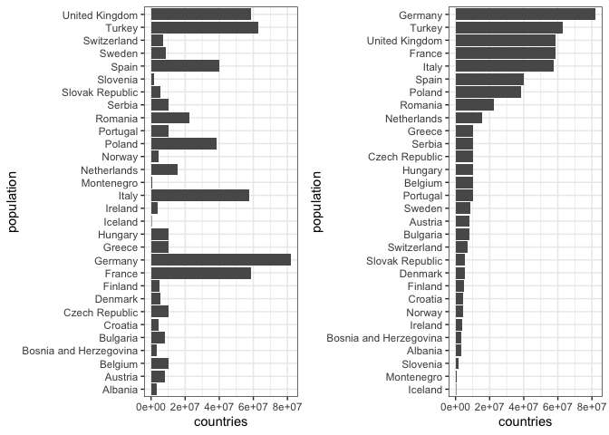

```r
gap_euro <- gapminder %>% filter(continent=="Europe",year =="1997")
p1<-gap_euro %>% ggplot(aes(x=(country),
              y = pop)) +
  geom_bar(stat="identity") +
  coord_flip()+
  ylab("countries") +
  xlab("population") +
  theme_bw() +
  theme(legend.position = "none")

p2<- gap_euro %>% ggplot(aes(y=pop,
             x =fct_reorder(gap_euro$country,
                            gap_euro$pop,
                            max, .incr=TRUE))) +
  geom_bar(stat="identity") +
  coord_flip() +
  ylab("countries") +
  xlab("population") +
  theme_bw() +
  theme(legend.position = "none")

# plot side by side
grid.arrange(p1,p2,ncol=2)
```

# 3 Exercise 3: File I/O

We will write and read to/from csv. The data that we will write to csv is:

```r
(cont_pop <- gapminder %>%
  group_by(continent) %>%
  summarise(avg_pop = mean(pop))) %>%
  kable()
```

| continent | avg_pop |
| --- | --- |
| Africa | 9916003 |
| Americas | 24504795 |
| Asia | 77038722 |
| Europe | 17169765 |
| Oceania | 8874672 |

Saving this `cont_pop` on disk:

```r
write_csv(cont_pop,
          here::here("hw5","exported_file.csv"))
```

```r
(imp_cont_pop <-
   read_csv(here::here("hw5",
                       "exported_file.csv"))) %>%
  kable()
```

| continent | avg_pop |
| --- | --- |
| Africa | 9916003 |
| Americas | 24504795 |
| Asia | 77038722 |
| Europe | 17169765 |
| Oceania | 8874672 |

We find that the class of the `continent` is now `character` instead of factor. We convert it back to a factor.

```r
# First convert it to tibble
imp_cont_pop <- as_tibble(imp_cont_pop)
imp_cont_pop$continent %>%
  class()
```

```
## [1] "character"
```

```r
# convert back to factor
imp_cont_pop$continent <- factor(imp_cont_pop$continent)

imp_cont_pop$continent %>%
  class()
```

```
## [1] "factor"
```

Now we order the dataset `imp_cont_pop` according to the population size.

```r
(ordered_dat <- imp_cont_pop %>%
  arrange(avg_pop)) %>% kable()
```

| continent | avg_pop |
| --- | --- |
| Oceania | 8874672 |
| Africa | 9916003 |
| Europe | 17169765 |
| Americas | 24504795 |
| Asia | 77038722 |

# 4 Exercise 4 : Visualization design

In Homework 3, I plotted the count of life expectancies across all the countries in the dataset, using histogram with: - Many bins (50). - A color palette, varying with respect to the count number. I thought this was a good idea, but turns out that it is distracting. - No proper x-axis label and no title.

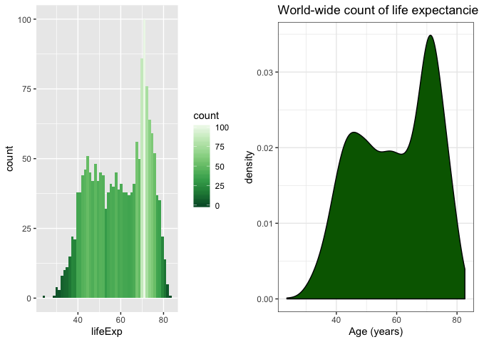

```r
q1 <-gapminder %>%
  ggplot(aes(lifeExp, color = lifeExp)) +
  geom_histogram(bins = 50, aes(fill=..count..)) +
  scale_fill_distiller(palette = "Greens")


q2<- gapminder %>%
  ggplot(aes(lifeExp)) +
  geom_density(fill="dark green") +
  theme_bw() +
  xlab("Age (years)") +
  ggtitle("World-wide count of life expectancies")

# plot side by side
(q3<-grid.arrange(q1,q2,ncol=2))
```

Now, instead of a histogram, I used a density plot. Density plot is a continuous version of the histogram. Notice that: - Instead of count on the y-axis, it shows the probability density function of the variable `lifeExp`. - Using many bins in a histogram smoothes the plot. `geom_density` allows me to easily take the limit of the number of bins. - A uniform color that is not distracting. - The axis labels are added.

# 5 Exercise 5 Saving figure

The last plot is `q3`, but we pass in the argument for `plot` anyways. If I wanted to save `p2` instead, passing in the argument `p2` is necessary.

```r
ggsave(here::here("hw5","plot_comparison.png"),
       plot=q3,width=15,height=15,dpi=300)
```

```r
ggsave(here::here("hw5","europe_pop.png"),
       plot=p2,width=15,height=15,dpi=300)
```

Notice that the text size is tiny. To resolve this, I would have to go back and change the font sizes in the figures. But for the purpose of this assignment, I will skip this.

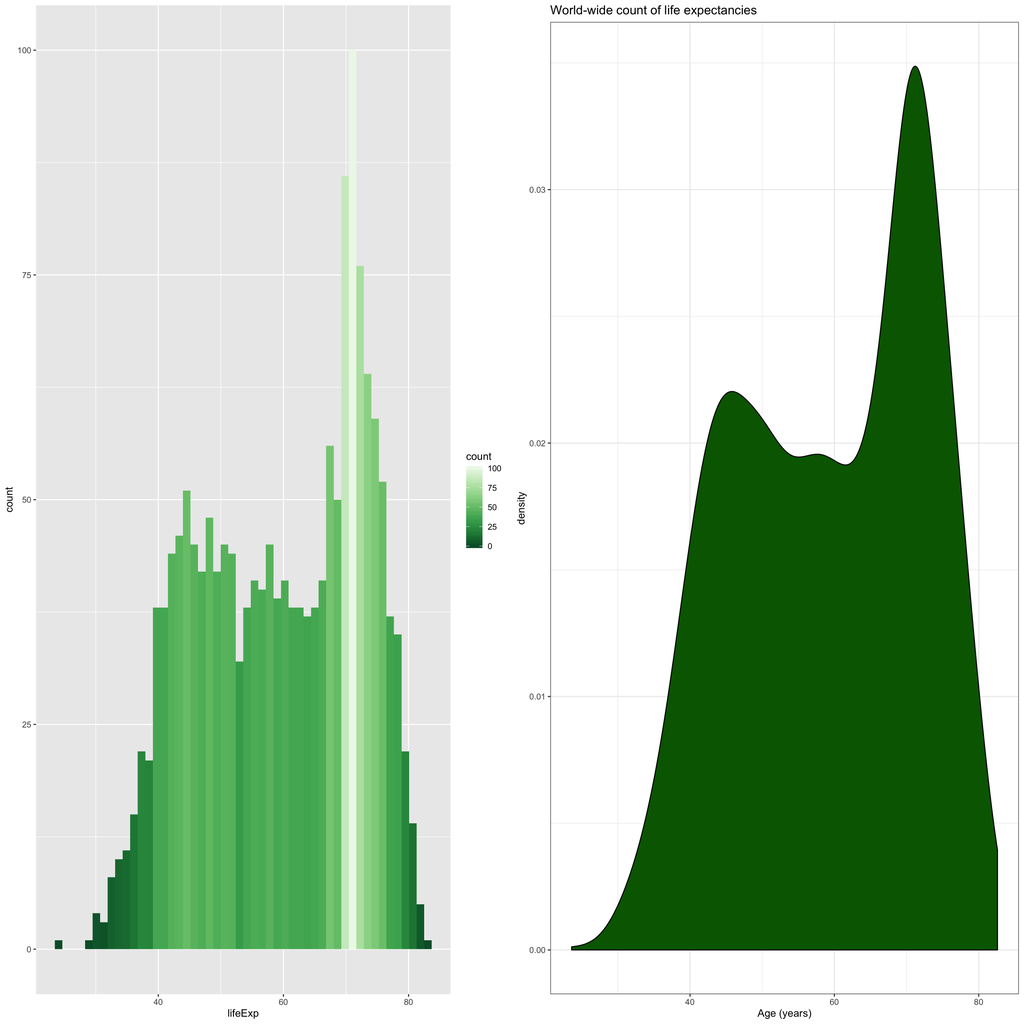

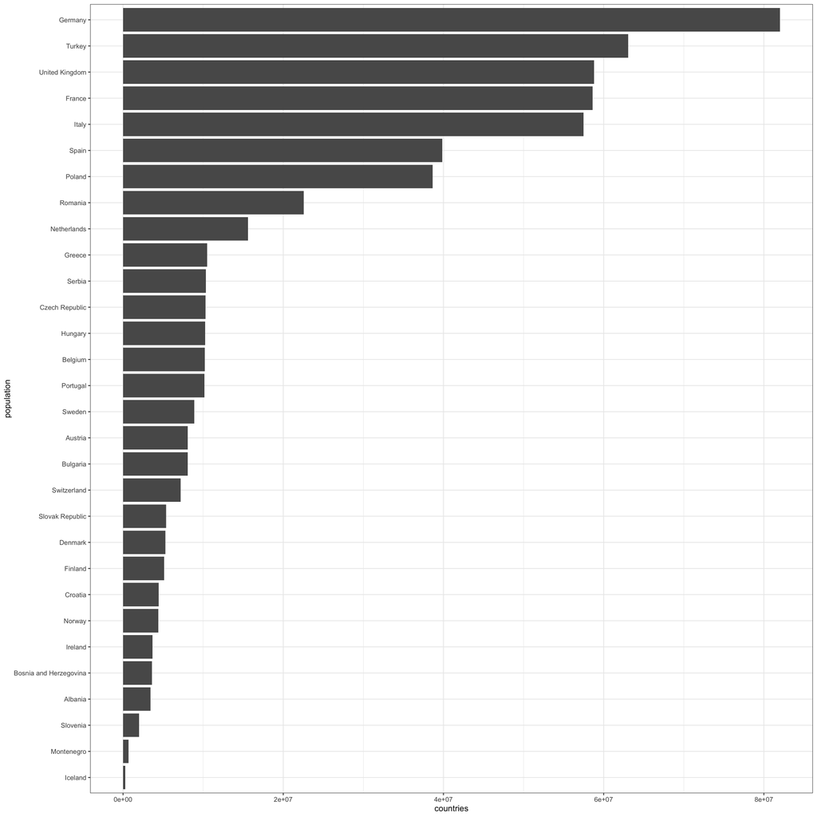